# From text to talk (ACL2022)

Mark Dingemanse & Andreas Liesenfeld

2022-03-20

> **Abstract:** Informal social interaction is the primordial home of human language. Linguistically diverse conversational corpora are an important and largely untapped resource for computational linguistics and language technology. Through the efforts of a worldwide language documentation movement, such corpora are increasingly becoming available. We show how interactional data from 63 languages (26 families) harbours insights about turn-taking, timing, sequential structure and social action, with implications for language technology, natural language understanding, and the design of conversational interfaces. Harnessing linguistically diverse conversational corpora will provide the empirical foundations for flexible, localizable, humane language technologies of the future.

# Introduction

This document produces the figures and analyses reported in the ACL2022 paper “From text to talk: Harnessing conversational corpora for humane and diversity-aware language technology”.

Not all of the languages or corpora are represented in all analyses and figures presented in the paper, because the corpora differ in size, precision of annotation, level of transcription. Accounts of inclusions and exclusions are provided in the reports by language.

**Note on data availability.** The corpora we rely on are made available for research purposes, but come under a variety of usage restrictions which in many cases (and for sensible reasons) prevent redistribution. We try to provide all relevant details about the corpora and how to access them in the following ways:

1. All corpora are cited in the paper with at least the name of the compilers and a durable HANDLE or DOI locator.
2. Links to all corpora and a considerable amount of additional data are also provided in the separate reports by language.
3. Our data curation workflow is detailed in [this preprint](https://doi.org/10.48550/arXiv.2203.03399).

This also means that the report below is based on the full data but we cannot share all of this data in the repository. Instead, we can share only derived measures and samples. We have tried to make our analysis as perspicuous as possible by including the code used to generate the measures and samples in the Rmd code.

# Data overview and map

The subset of corpora considered here amounts to around 800 hours of speech, or 9.3 million words, segmented into 1.6 million annotations produced by over 11.000 participants.

| language | turns | words | minutes | hours | people |
| --- | --- | --- | --- | --- | --- |
| +Akhoe | 721 | 3253 | 28.70883 | 0.4784806 | 18 |
| Akpes | 635 | 3965 | 17.76610 | 0.2961017 | 4 |
| Ambel | 1509 | 6601 | 42.01975 | 0.7003292 | 22 |
| Anal | 6767 | 26826 | 277.70990 | 4.6284983 | 54 |
| Arabic | 33120 | 201207 | 1211.11098 | 20.1851831 | 365 |
| Arapaho | 4821 | 55850 | 243.49993 | 4.0583322 | 109 |
| Baa | 1361 | 12553 | 65.25307 | 1.0875511 | 7 |
| Br. Portuguese | 3242 | 17109 | 88.40308 | 1.4733847 | 2 |
| Catalan | 11059 | 93827 | 398.31698 | 6.6386164 | 83 |
| Chitkuli | 1123 | 13462 | 68.30572 | 1.1384286 | 20 |

[output cut: 53 more lines]

We generate a map with numbers for labels (used in the paper).

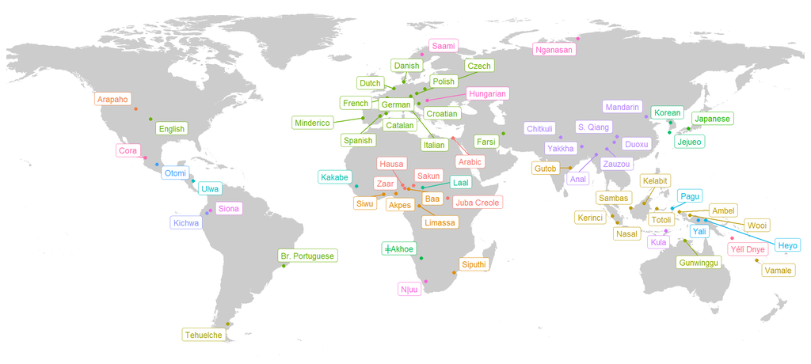

We also produce a graph of language resources by size.

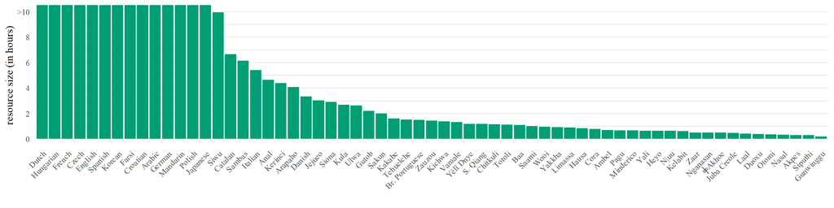

# Turn-taking & timing

We look at the timing of turn-taking in sufficiently large corpora, limiting the analysis to dyadic interactions because triadic and multi-party interaction is qualitatively different. We determine participation framework based on a 10 second rolling window: if in the window there are no more than 2 participants we count the interaction at that point as dyadic.

Five corpora are excluded from these analyses because they have unclear or incommensurable segmentation conventions: Brazilian Portuguese, Croatian, Czech, Hungarian, and Nganasan. A further number of corpora do not feature at least 1000 dyadic turn transitions.

[figure not shown]

# Unity and diversity

As a language-agnostic approach to activity types, we consider a distinction between ‘chats’ and ‘chunks’. We identify a number of these and plot them in six unrelated languages. Chunks are identified by looking for streaks of >2 identical turns by the same participant occurring in close succession while they make up less than 30% of talk in the surrounding 10 second window.

Chats are identified by looking for turns with a duration of 3 seconds that occur in a regime where contributions in the 10 second window surrounding them are evenly distributed (both speakers contribution between 40% to 60% of talk).

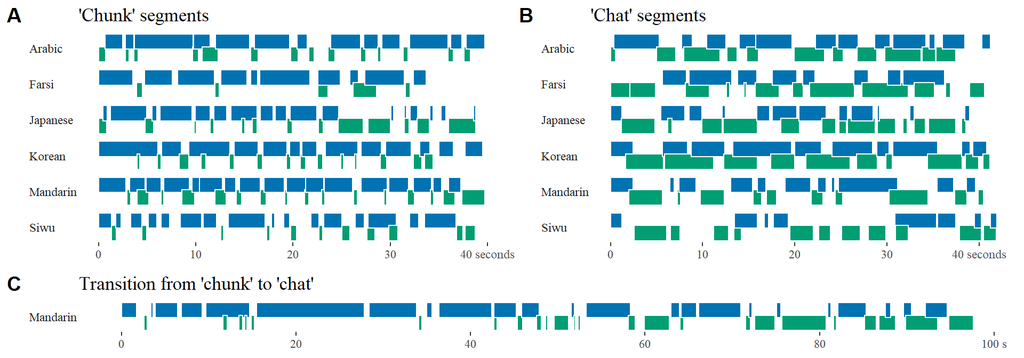

We find that the most frequent turn formats used in English and Korean tellings are ‘mhm’ and ‘eung’ respectively. We plot 4 examples of 80 second stretches featuring continuers, and sample 100 such segments for each of the languages to compare the relative frequency of continuers.

We sample 100 stretches of 80000 ms (80 s) in each of the languages.

The sample is randomized each time, but with the seed used in the paper, we end up with 100 samples from 53 Korean source recordings with 106 distinct participants, and another 100 samples from 55 English source recordings with 96 distinct participants.

Here are the basic descriptive statistics for number of total turns, mean number of continuers, and overlap.

| langshort | n_turns | mean_cont | n_cont_sd | mean_rel | n_rel_sd | mean_inv | n_inv_sd | mean_overlap |
| --- | --- | --- | --- | --- | --- | --- | --- | --- |
| English | 30.51 | 2.56 | 1.707500 | 0.09201101 | 0.08589379 | 14.542897 | 12.760300 | 0.3681159 |
| Korean | 35.68 | 6.98 | 4.218717 | 0.20091030 | 0.10278029 | 6.988365 | 4.952738 | 0.7369223 |

Note that average duration and number of turns per 10 second window is not very different across the two languages, so won’t really explain this:

| language | meanduration | turnsper10sec | wordsperturn |
| --- | --- | --- | --- |
| english | 1871.215 | 5.641431 | 6.846963 |
| korean | 2545.308 | 5.550760 | 5.739581 |

Putting it all together, we get at the following figure:

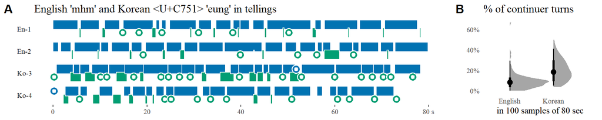

# Interactional tools

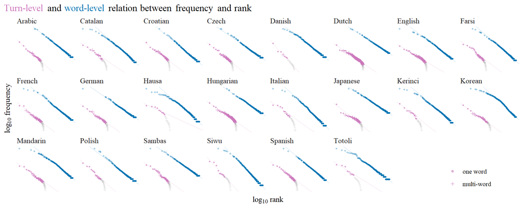

## Recurrent turn formats

What is the proportion of multiword versus one word recurrent turn formats?

| words | n | prop |
| --- | --- | --- |
| more | 225 | 0.4 |
| one | 370 | 0.6 |

# Appendices

## Validation of turn-taking measures

Stivers et al. 2009 work with polar questions only. We can try to approach that by looking at all FTOs of turn types that are reasonably frequent (= likely to be conventionalized responses to polar questions) that follow turns that end in a question mark.

We limit ourselves to languages in which 250 such sequences are found. Here are, for each of these 10 languages, one example of a candidate QA sequence so identified:

| language | Q | A |
| --- | --- | --- |
| Catalan | a quina hora li he dit que arribava? | sí |
| Dutch | maar een zomerjurk? | ja |
| English | thats going to your house right? | yeah |
| German | und äh wir waren jetzt ja äh äh soll ich dir mal alles der Reihe nach erzählen? | ja |
| Kerinci | lebih baik itòh bé jadi maharnyo kan? | iyò |
| Korean | ja-gi-do geu teum-e ggi-eo-seo gan geo-ya? | eung |
| Mandarin | hao de hao de hao de hao jiu zhege shiqing shiba? | e |
| Polish | a czy znala jezyk litewski? | mhm |
| Sambas | itoq lah anak béduwaq i? | eeq |
| Spanish | oye y la estela cómo está? | sí |

Then we print the number of candidate QA sequences by language and plot the distribution of FTOs (floor transfer onset times).

| language | n |
| --- | --- |
| Catalan | 930 |
| Dutch | 557 |
| English | 1230 |
| German | 1540 |
| Kerinci | 682 |
| Korean | 4294 |
| Mandarin | 2698 |
| Polish | 685 |
| Sambas | 501 |
| Spanish | 2363 |

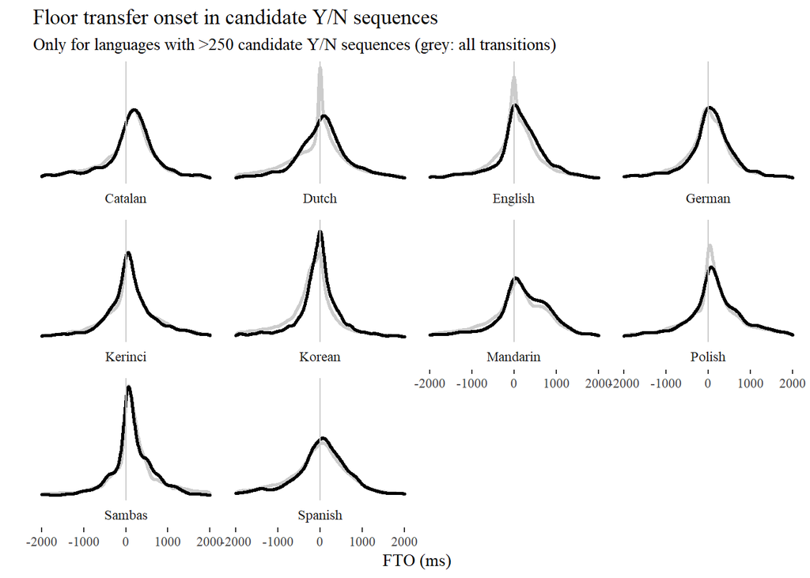

## Power law plots for smaller corpora

While the body of the paper provides a plot for 22 large corpora, here we als plot the rank-frequency distributions for turns and words for 21 smaller corpora in which there are at least 9 recurrent turn formats.

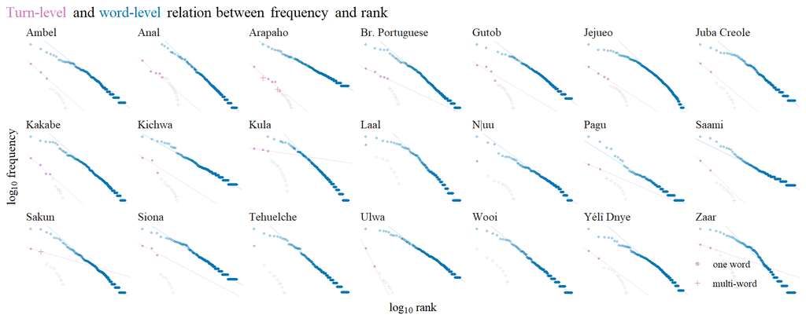

## Table of language data

This table shows language name, family, glottocode and citation key. The paper contains full bibliographic metadata.

| Language | Family | glottocode | Citation |
| --- | --- | --- | --- |
| +Akhoe | Khoe-Kwadi | haio1238 | widlokCollectionAkhoeHai2007 |
| Akpes | Atlantic-Congo | akpe1248 | lauDocumentingAbesabesi2019 |
| Ambel | Austronesian | waig1244 | arnoldDocumentationAmbelAustronesian2017 |
| Anal | Sino-Tibetan | anal1239 | ozerovCommunitydrivenDocumentationNatural2018 |
| Arabic | Afro-Asiatic | egyp1253 | canavanalexandraCALLHOMEEgyptianArabic1997 |
| Arapaho | Algic | arap1274 | cowellConversationalDatabaseArapaho1950 |
| Baa | Atlantic-Congo | kwaa1262 | mollernwadigoDocumentationProjectBaa2016 |
| Br. Portuguese | Indo-European | braz1246 | dasilvaProjetoNormaUrbana1996 |
| Catalan | Indo-European | stan1289 | garridoGlissandoCorpusMultidisciplinary2013 |
| Chitkuli | Sino-Tibetan | chit1279 | martinezDocumentaryCorpusChhitkulRakchham2020 |

[output cut: 53 more lines]